# mvgam case study 2: multivariate models

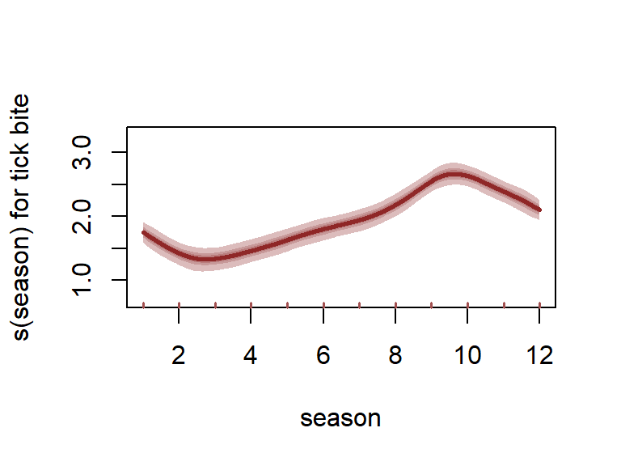

```r
plot_mvgam_smooth(object = trends_mod3, series = 3,
    smooth = "season")
```

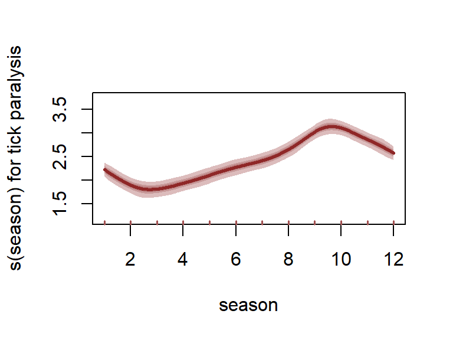

```r
plot_mvgam_smooth(object = trends_mod3, series = 4,
    smooth = "season")
```

Plot posterior mean estimates of latent trend correlations. These correlations are more useful than looking at latent factor loadings, for example to inspect ordinations. This is because the orders of the loadings (although constrained for identifiability purposes) can vary from chain to chain

```r
correlations <- lv_correlations(object = trends_mod3)
```

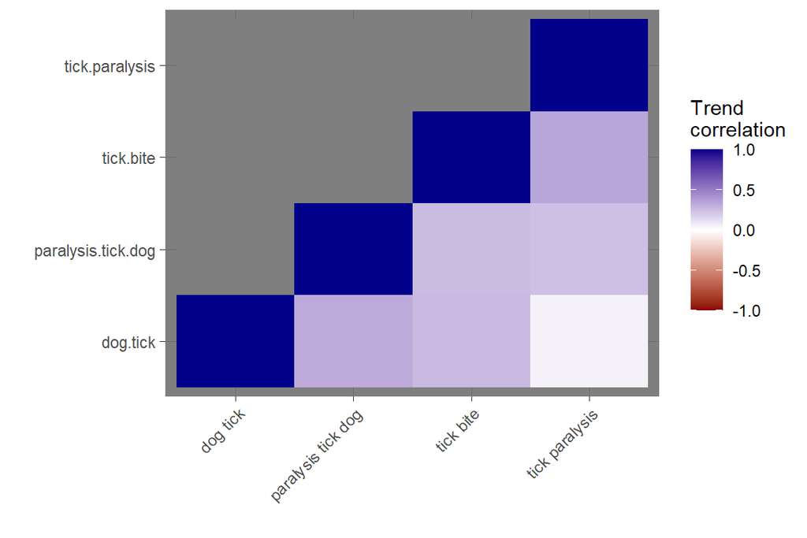

```r
library(ggplot2)
mean_correlations <- correlations$mean_correlations
mean_correlations[upper.tri(mean_correlations)] <- NA
mean_correlations <- data.frame(mean_correlations)
ggplot(mean_correlations %>% tibble::rownames_to_column("series1") %>%
    tidyr::pivot_longer(-c(series1), names_to = "series2",
        values_to = "Correlation"), aes(x = series1,
    y = series2)) + geom_tile(aes(fill = Correlation)) +
    scale_fill_gradient2(low = "darkred",
        mid = "white", high = "darkblue",
        midpoint = 0, breaks = seq(-1, 1,
            length.out = 5), limits = c(-1,
            1), name = "Trend\ncorrelation") +
    labs(x = "", y = "") + theme_dark() +
    theme(axis.text.x = element_text(angle = 45,
        hjust = 1))
```

There is certainly some evidence of positive trend correlations for a few of these search terms, which is not surprising given how similar some of them are and how closely linked they should be to interest about tick paralysis in Queensland. Plot some STL decompositions of these series to see if these trends are noticeable in the data

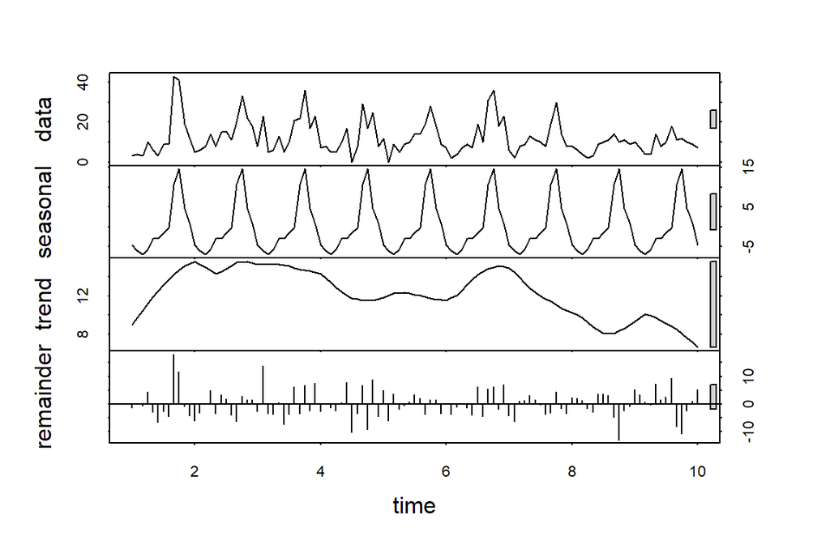

```r
plot(stl(ts(as.vector(series$`tick paralysis`),
    frequency = 12), "periodic"))
```

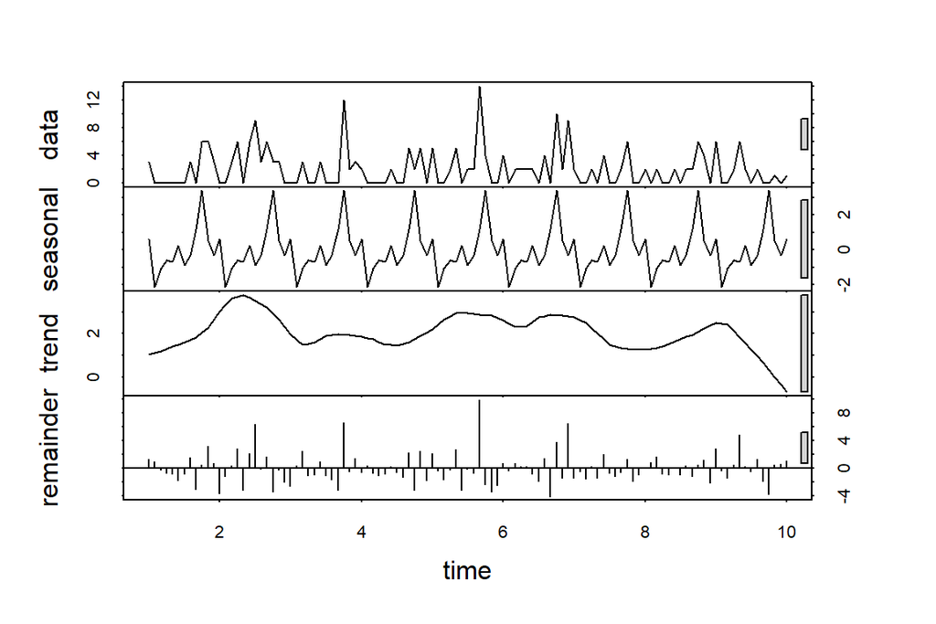

```r
plot(stl(ts(as.vector(series$`paralysis tick dog`),
    frequency = 12), "periodic"))
```

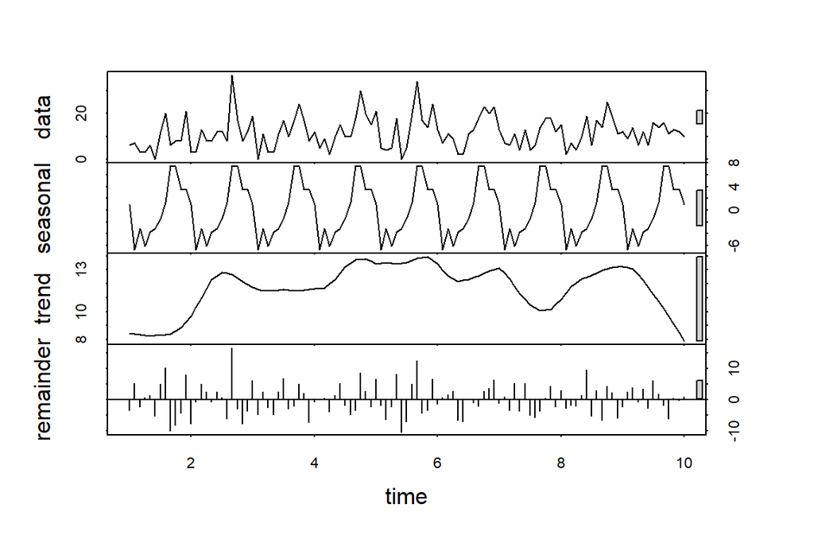

```r
plot(stl(ts(as.vector(series$`dog tick`),
    frequency = 12), "periodic"))
```

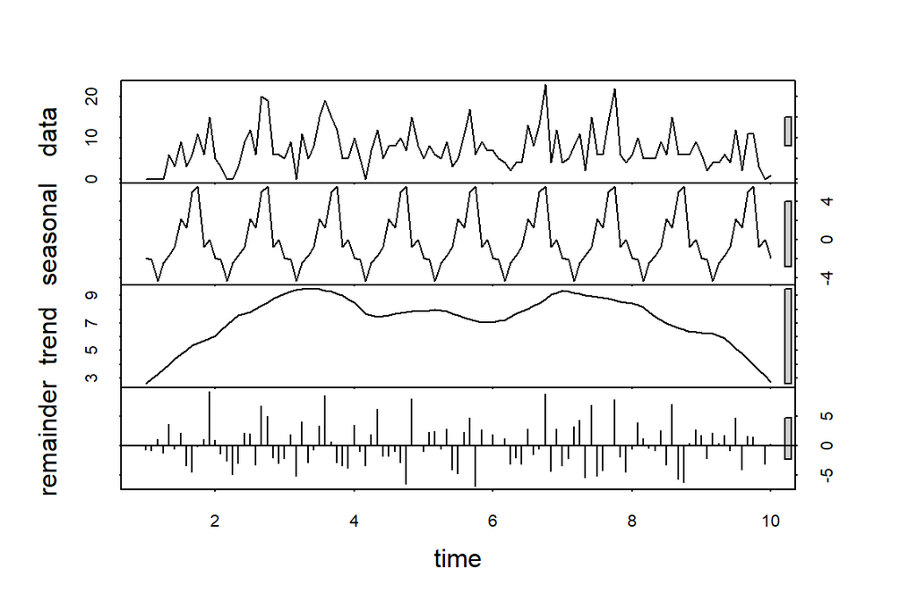

```r
plot(stl(ts(as.vector(series$`tick bite`),
    frequency = 12), "periodic"))
```

Forecast period posterior predictive checks suggest that the model still has room for improvement:

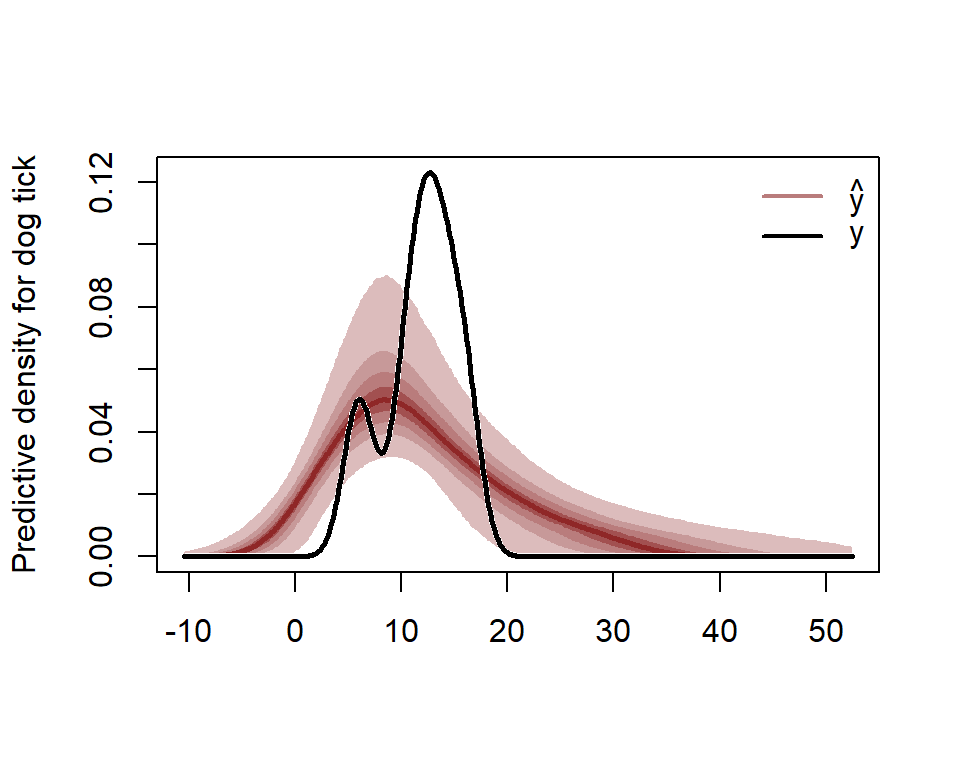

```r
plot_mvgam_ppc(trends_mod3, series = 1, type = "density",
    data_test = trends_data$data_test)
```

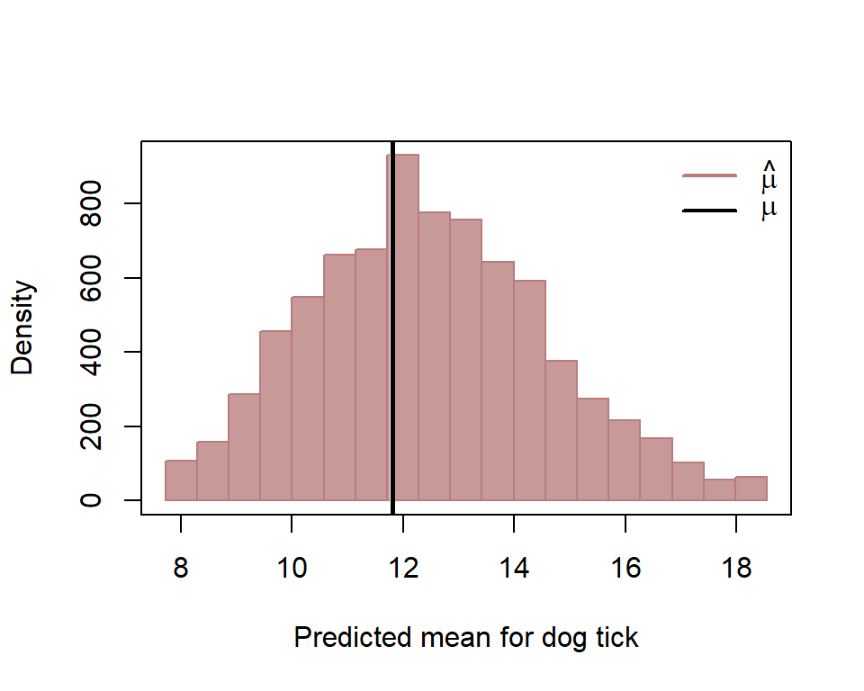

```r
plot_mvgam_ppc(trends_mod3, series = 1, type = "mean",
    data_test = trends_data$data_test)
```

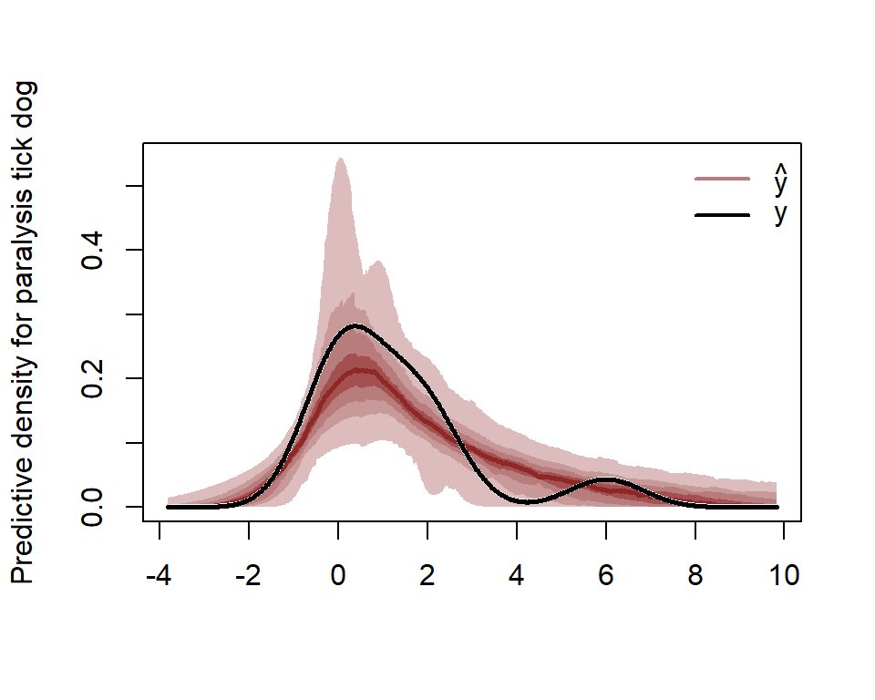

```r
plot_mvgam_ppc(trends_mod3, series = 2, type = "density",
    data_test = trends_data$data_test)
```

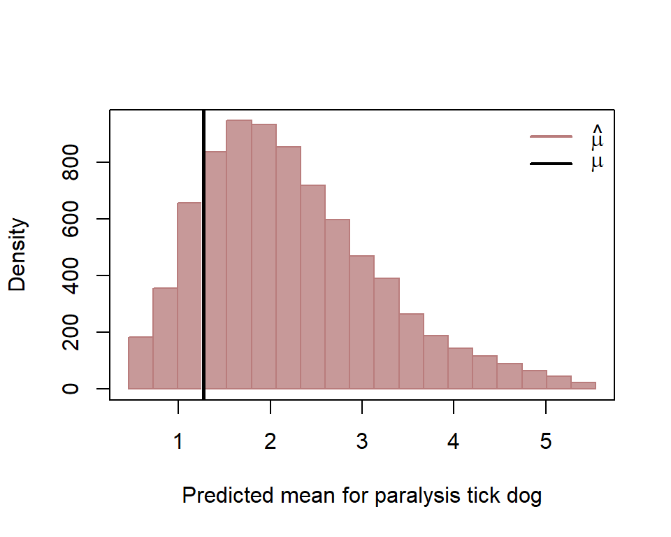

```r
plot_mvgam_ppc(trends_mod3, series = 2, type = "mean",
    data_test = trends_data$data_test)
```

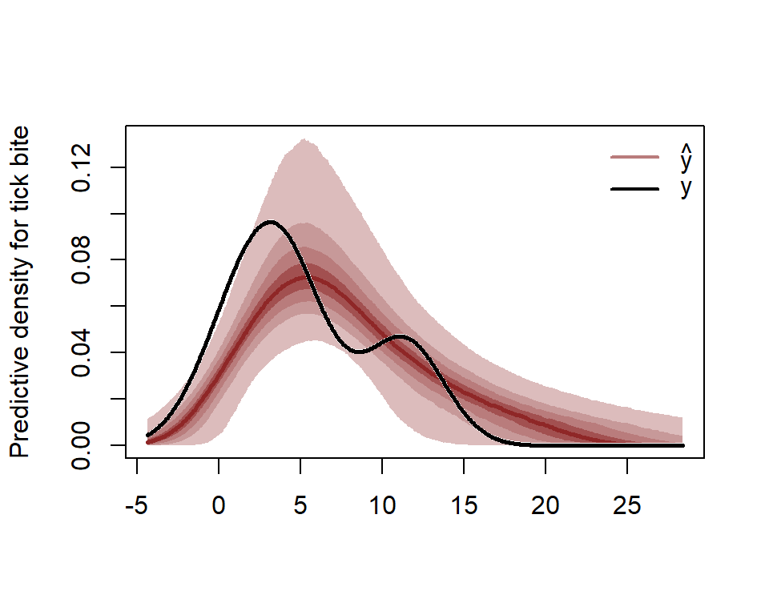

```r
plot_mvgam_ppc(trends_mod3, series = 3, type = "density",
    data_test = trends_data$data_test)
```

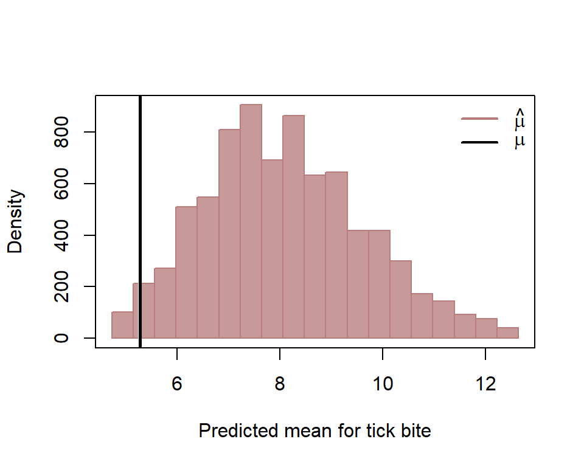

```r
plot_mvgam_ppc(trends_mod3, series = 3, type = "mean",
    data_test = trends_data$data_test)
```

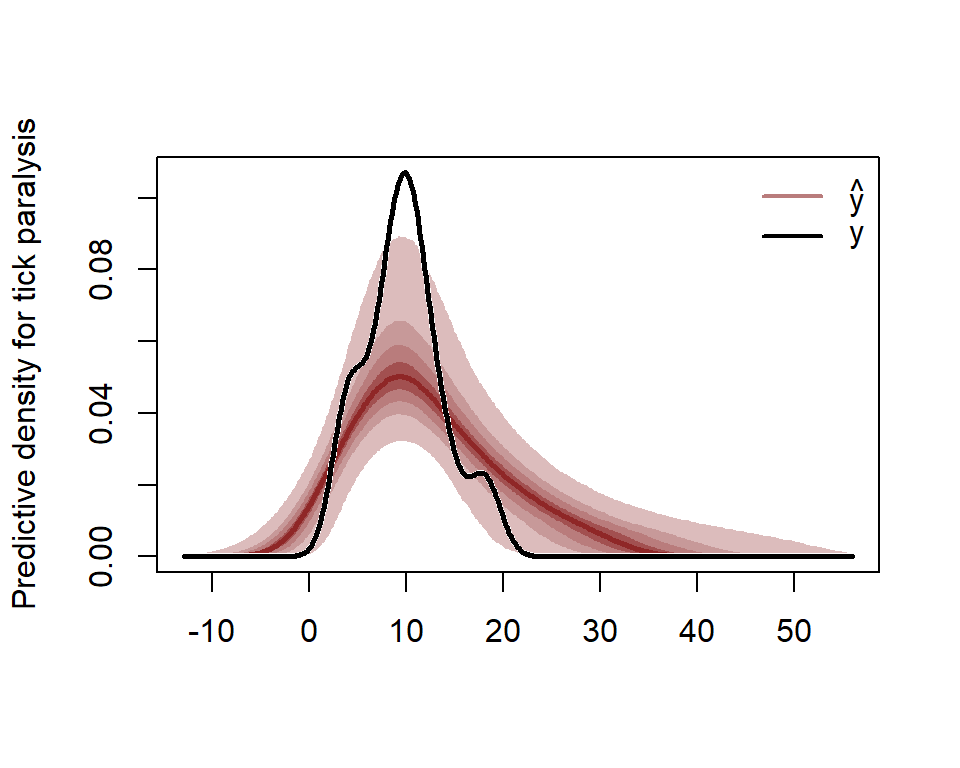

```r
plot_mvgam_ppc(trends_mod3, series = 4, type = "density",
    data_test = trends_data$data_test)
```

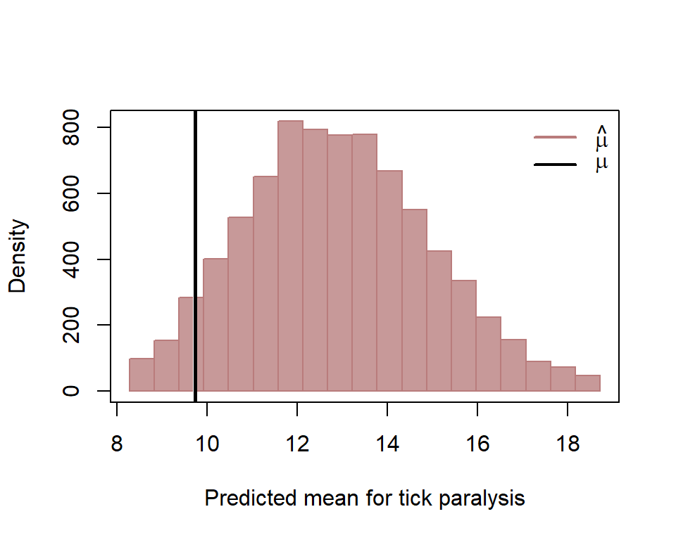

```r
plot_mvgam_ppc(trends_mod3, series = 4, type = "mean",
    data_test = trends_data$data_test)
```

Other next steps could involve devising a more goal-specific set of posterior predictive checks (see [this paper by Gelman et al](https://www.jstor.org/stable/2680852?seq=1#metadata_info_tab_contents) and [relevant works by Betancourt](https://betanalpha.github.io/assets/case_studies/principled_bayesian_workflow.html) for examples) and compare out of sample Discrete Rank Probability Scores for this model and other versions for the latent trends (i.e. AR2, AR3, Random Walk)